# Working with data (tidyr and dplyr)

## Advanced tidyverse: integrating tidyr with ggplot

We can actually use pipes to process data and input these data directly into ggplot! Let’s use some of the skills you’ve acquired above and the *Rana* data from Day 5 to build some interesting plots.

1. Read in the `rana_stats.txt` file from Day 5 (it’s within the Day 6 directory too) and save it as `stats`.

```r
stats <- read_tsv(here("data", "Day6_tidyr_worksheet_files/rana_stats.txt"))
```

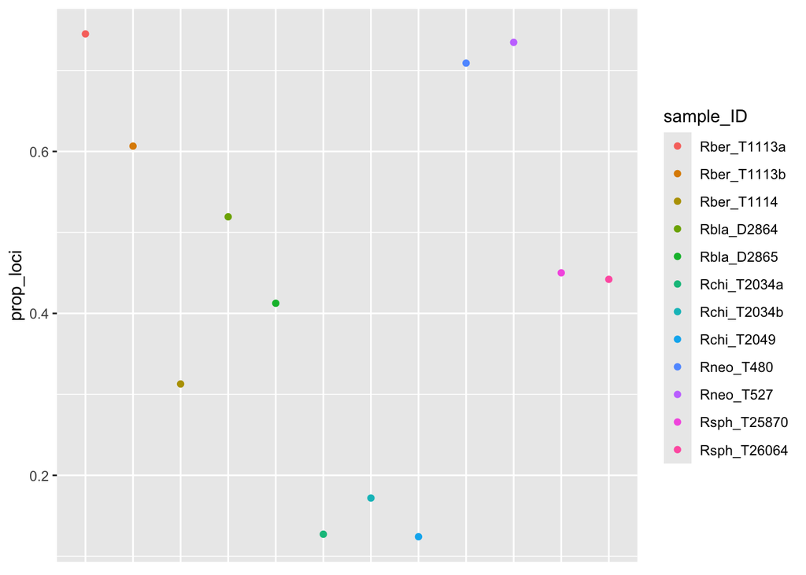

```r
stats %>%
  mutate(prop_loci = loci_in_assembly / 20486) %>%
  ggplot(aes(x = sample_ID, y = prop_loci, color = sample_ID)) +
  geom_point() +
  theme(axis.title.x = element_blank(),
        axis.text.x = element_blank(),
        axis.ticks.x = element_blank())
```

3. Export your plot as a PDF.

```
ggsave(here("props_loci.pdf"))
```

## Advanced tidyverse: integrating tidyr with ggtree

1. Import the `ranaddrad_tree.nexus` file as you did on Day 5.

```r
library(ape)
library(ggtree)
tree <- read.nexus(here("data", "ranaddrad_tree.nexus"))
```

2. Root the tree at node 21 so that *R. chiricahuensis* is the outgroup clade.

```r
rooted_tree <- root(tree, node = 21, edgelabel = TRUE)
```

3. Build a tree plot with tip labels and a scale.

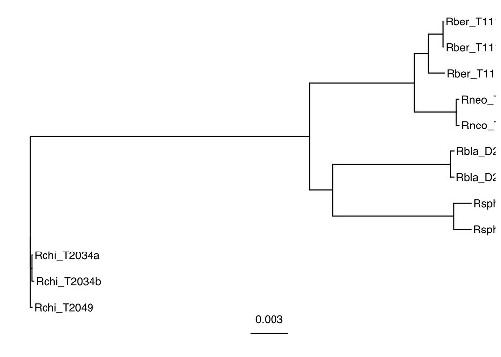

```r
tree_plot <-
  ggtree(rooted_tree) +
  geom_tiplab() +
  theme(legend.position = "bottom") +
  geom_treescale()
tree_plot
```

4. What is the maximum number of consensus reads in any given sample?

```r
stats %>%
  summarize(max(reads_consens))
```

```
## # A tibble: 1 × 1
##   `max(reads_consens)`
##                  <dbl>
## 1                34309
```

```r
# You could also do:
max(stats$reads_consens)
```

```
## [1] 34309
```

5. Now, *in a single line of code*, make a new column in the `stats` dataframe called `prop_reads` that is the proportion of consensus reads that each sample has divided by the maximum number of reads across all the samples.

```r
stats <-
  stats %>%
  mutate(prop_reads = reads_consens / max(reads_consens))
```

6. Add the `prop_reads` for each sample as colored tips on the phylogeny.

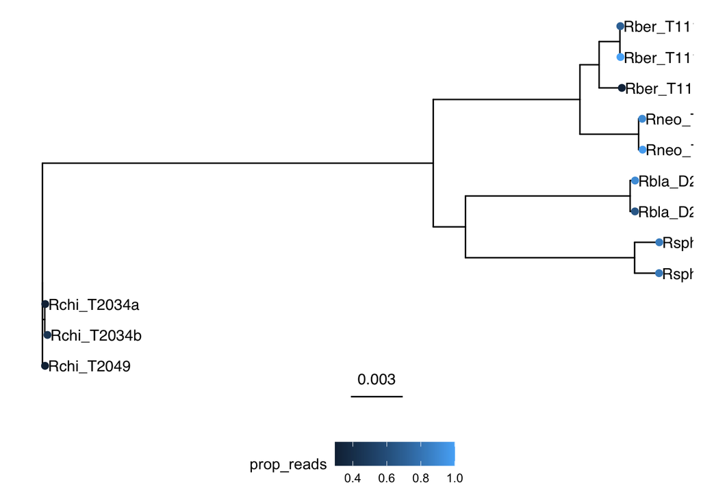

```r
tree_plot %<+%
  stats +
  geom_tippoint(aes(color = prop_reads), size = 2)
```

7. Export your new tree plot as a PDF.

```
ggsave(here("prop_reads_plot.pdf"))
```